# Variation in z

Francesco Polazzo

17 March, 2023

# 1 Intention

In this document, we are going to explore how diversity in species responses to one or both environmental variables, and different scenarios of correlation between them, may influence multifarious response diversity. Additionally, we are going to look how different correlation between the environmental variables influence the calculated response diversity.

Within the project “response diversity in the context of multifarious environmental change”, we have been simulating species response curves using the Eppley performance curve.

With one environmental variable, the performance (i.e., rate) is given by:

- $rate(E) = ae^{bE}(1 - (\frac{E - z}{w/2})^2)$
- $E$ is the values of the environmental factor.
- $z$ controls location of maximum.
- $w$ controls range of $E$ over which the rate is positive.
- $a$ scaling constant.
- $b$ controls rate of increase towards the maximum rate, as $E$ increases.

Adding a second environmental variable gives:

$rate(E_1, E_2) = a_1e^{b_1E_1}(1 - (\frac{E_1 - z_1}{w_1/2})^2) + a_2e^{b_2E_2}(1 - (\frac{E_2 - z_2}{w_2/2})^2)$

We now want to assess the role of diversity in response to on (or both) environmental variable(s), and investigate how different covariances in diversity of responses to E1 and E2 influence response diversity.

To do that, we are going to manipulate amount of diversity in responses to either or both env variables among the species, and also the correlation in the tolerances (position of optima, determine by the terms z1 and z2 in the above formula). We will make scenarios of communities with diversity in response to only E1, or both E1 and E2, with diversity in both that is positively correlated (co-tolerance) or negatively (anti-tolerance) or no correlation.

# 2 Variation in diversity in z1

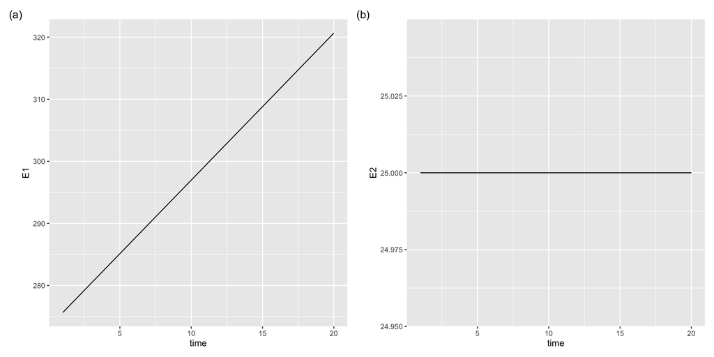